# Coursera Statistical Inference Project (Part 1): Simulation to Explore Inferences

mjurado

Thursday, March 12, 2015

#### Overview

The goal of this analysis is to explore inferences in order to compare the sample means versus the theoretical mean of the distribution as well as compare the sample variance versus the theoretical variance of the distribution. In the end I will prove that the distribution is approximately normal.

#### Simulations

##### Analysis 1: Mean comparisons

```r
# Set given information
n <- 40 # number of exponentials
lambda <- .2 # rate
theo.mean <- round(1/ lambda,3) # <- theoretical mean of the distribution
theo.std.dev <- theo.mean
theo.std.err <- theo.std.dev/sqrt(n)
sim.cnt.small <- 10
sim.cnt.big <- 1000

# Calculation the sample mean for 10 simulations
sample.sim.small = NULL
for (i in 1 : 10) sample.sim.small[i] = mean(rexp(n,lambda))
sample.mean.small <- round(mean(sample.sim.small),3)

# Calculate the sample mean over 1000 simulations
sample.sim.big = NULL
for (i in 1 : 1000) sample.sim.big[i] = mean(rexp(n,lambda))
sample.mean.big <- round(mean(sample.sim.big),3)
```

##### Show the sample mean and compare it to the theoretical mean of the distribution.

- The sample center of distribution for 10 simulations is: 5.16.
- The sample center of distribution for 1000 simulations is: 5.008.
- The theoretical center of distribution is: 5.

*Conclusion: As you can see when the number of simulations increase the center of distribution gets closer to the theoretical center of distribution.*

##### Analysis 2: Variance comparisons

```r
# Determine the big and small sample variances
sample.var.small <- sample.mean.small^2
sample.var.big <- sample.mean.big^2

# Determine the variance of the theoretical distribution
theo.var <- theo.std.dev^2
```

##### Show how variable the sample is (via variance) and compare it to the theoretical variance of the distribution.

The variance of an exponential distribution is the square of the mean, therefore, we get:

- The small sample variance is: 26.6256.
- The large sample variance is: 25.080064.
- The theoretical variance is: 25.

Conclusion: As you can see, the greater the number of simulations, the closer the variances gets to the theoretical variance.

##### Analysis 3: Show that the distribution is approximately normal.

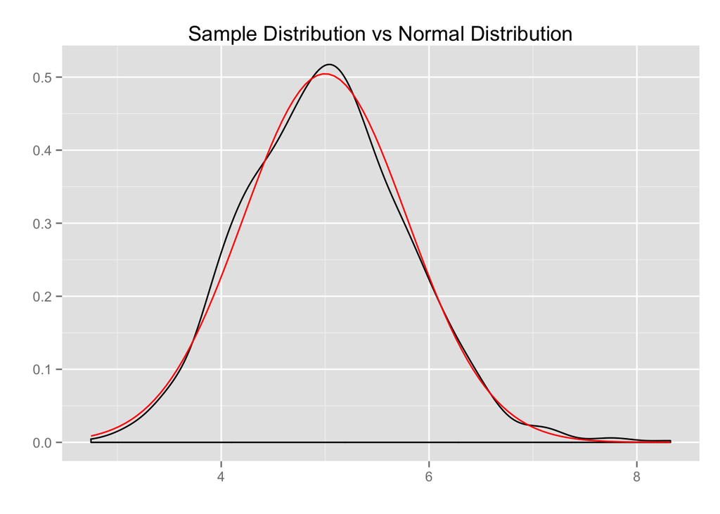

```r
library(ggplot2)
dist <- qplot(sample.sim.big,
              geom = "density",
              xlim= c(min(sample.sim.big),max(sample.sim.big)),
              xlab = "",
              ylab = "",
              main="Sample Distribution vs Normal Distribution")
dist + stat_function(fun = dnorm, colour = "red", args=list(mean=theo.mean, sd=theo.std.err))
```